# **Part A: Convolutional Neural Network**

### CutMix data augmentation

Cutmix Data Augmentation is

- Cut and paste random patches between the training images
- Ground truth labels are mixed in proportion to the area of patches in the images
- It increases localisation ability by making the model to focus on less discriminative parts of the object being classified and hence is also well suited for tasks like object detection

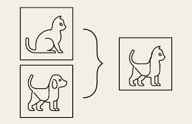

```python
def preprocess_data(image, label):
  image = tf.expand_dims(image, -1)
  return image, label

def sample_beta_distribution(size, concentration_0=300, concentration_1=0.1):
  gamma_1_sample = tf.random.gamma(shape=[size], alpha=concentration_1)
  gamma_2_sample = tf.random.gamma(shape=[size], alpha=concentration_0)
  return gamma_1_sample / (gamma_1_sample + gamma_2_sample)


@tf.function
def get_box(lambda_value):
  cut_rat = tf.math.sqrt(1.0 - lambda_value)
  image_wh = (31,31,1)[0]
  cut_wh = image_wh * cut_rat  # rw
  cut_wh = tf.cast(cut_wh, tf.int32)

  cut_x = tf.random.uniform((1,), minval=0, maxval=image_wh, dtype=tf.int32)  # rx
  cut_y = tf.random.uniform((1,), minval=0, maxval=image_wh, dtype=tf.int32)  # ry

  boundaryx1 = tf.clip_by_value(cut_x[0] - cut_wh // 2, 0, image_wh)
  boundaryy1 = tf.clip_by_value(cut_y[0] - cut_wh // 2, 0, image_wh)
  bbx2 = tf.clip_by_value(cut_x[0] + cut_wh // 2, 0, image_wh)
  bby2 = tf.clip_by_value(cut_y[0] + cut_wh // 2, 0, image_wh)

  target_h = bby2 - boundaryy1
  if target_h == 0:
      target_h += 1

  target_w = bbx2 - boundaryx1
  if target_w == 0:
      target_w += 1

  return boundaryx1, boundaryy1, target_h, target_w


@tf.function
def cutmix(train_ds_one, train_ds_two):
  (image1, label1), (image2, label2) = train_ds_one, train_ds_two
  image_size = (31,31,1)[0]
  alpha = [1]
  beta = [1]
  lambda_value = sample_beta_distribution(1, alpha, beta)
  lambda_value = lambda_value[0][0]
  boundaryx1, boundaryy1, target_h, target_w = get_box(lambda_value)
  crop2 = tf.image.crop_to_bounding_box(
      image2, boundaryy1, boundaryx1, target_h, target_w
  )
  image2 = tf.image.pad_to_bounding_box(
      crop2, boundaryy1, boundaryx1, image_size, image_size
  )
  crop1 = tf.image.crop_to_bounding_box(
      image1, boundaryy1, boundaryx1, target_h, target_w
  )
  img1 = tf.image.pad_to_bounding_box(
      crop1, boundaryy1, boundaryx1, image_size, image_size
  )

  image1 = image1 - img1
  image = image1 + image2
  lambda_value = 1 - (target_w * target_h) / (image_size * image_size)
  lambda_value = tf.cast(lambda_value, tf.float32)
  label = lambda_value * label1 + (1 - lambda_value) * label2
  return image, label
```

#### Set up the train and validation data

```python
train_ds_one = tf.data.Dataset.from_tensor_slices((X_train_small, y_train_small)).shuffle(2048).map(preprocess_data, num_parallel_calls=tf.data.AUTOTUNE)
train_ds_two = tf.data.Dataset.from_tensor_slices((X_train_small, y_train_small)).shuffle(2048).map(preprocess_data, num_parallel_calls=tf.data.AUTOTUNE)

val_ds_cutmix = tf.data.Dataset.from_tensor_slices((X_val_small, y_val_small))
val_ds_cutmix = val_ds_cutmix.map(preprocess_data, num_parallel_calls=tf.data.AUTOTUNE).batch(128).prefetch(tf.data.AUTOTUNE)

train_ds_cutmix = tf.data.Dataset.zip((train_ds_one, train_ds_two))
train_ds_cutmix = (
    train_ds_cutmix.shuffle(1024)
    .map(cutmix, num_parallel_calls=tf.data.AUTOTUNE)
    .batch(128)
    .prefetch(tf.data.AUTOTUNE)
)
train_ds_cutmix
image_batch, label_batch = next(iter(train_ds_cutmix))
```

#### Visualisation of the augmented dataset

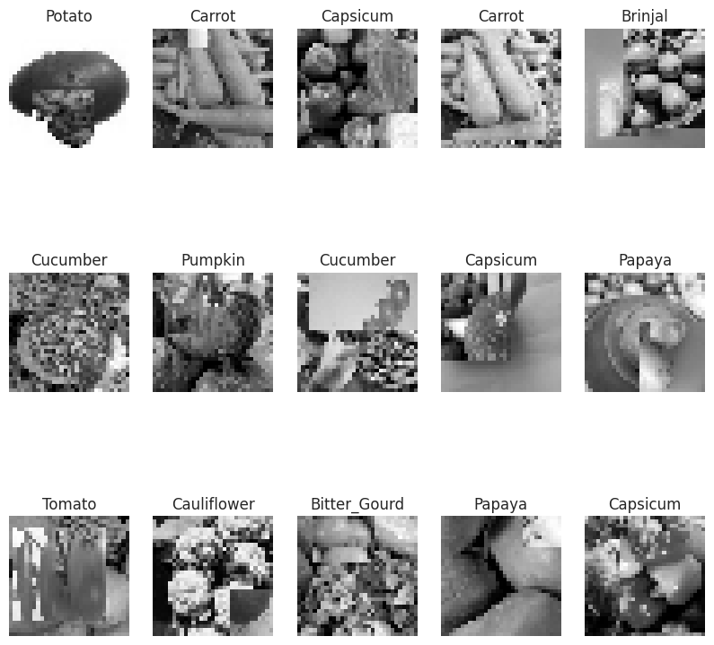

```python
plt.figure(figsize=(10, 10))
for i in range(15):
    ax = plt.subplot(3, 5, i + 1)
    plt.title(labels_dict[np.argmax(label_batch[i])])
    plt.imshow(tf.squeeze(image_batch[i]), cmap="gray")
    plt.axis("off")
plt.show()
```

#### Running the models

```python
models = models_array()
figures_cutmix = []

for i in range(len(models)):
    print(f'Running {model_names[i]}')
    results, fig = evaluator.model_evaluate( train_ds_cutmix, val_ds_cutmix , models[i], base_hparams)
    results['Model Name'] = f'{model_names[i]} cutmix'
    y_pred = models[i].predict(X_test_small)
    y_pred_classes = np.argmax(y_pred, axis=1)

    kappa = cohen_kappa_score(y_test_small, y_pred_classes)
    print("Cohen’s Kappa Score:", kappa)
    results['Kappa'] = kappa
    overall = pd.concat([overall, pd.DataFrame([results])], ignore_index=True)
    figures_cutmix.append(fig)
```

```
Model: "sequential_16"
_________________________________________________________________
 Layer (type)                Output Shape              Param #
=================================================================
 conv2d_11 (Conv2D)          (None, 31, 31, 128)       1280

 batch_normalization_11 (Bat  (None, 31, 31, 128)      512
 chNormalization)

 re_lu_11 (ReLU)             (None, 31, 31, 128)       0

 conv2d_12 (Conv2D)          (None, 31, 31, 128)       147584

 batch_normalization_12 (Bat  (None, 31, 31, 128)      512
 chNormalization)

 re_lu_12 (ReLU)             (None, 31, 31, 128)       0

 conv2d_13 (Conv2D)          (None, 31, 31, 128)       147584

 batch_normalization_13 (Bat  (None, 31, 31, 128)      512
 chNormalization)

 re_lu_13 (ReLU)             (None, 31, 31, 128)       0

 conv2d_14 (Conv2D)          (None, 31, 31, 128)       147584

 batch_normalization_14 (Bat  (None, 31, 31, 128)      512
 chNormalization)

 re_lu_14 (ReLU)             (None, 31, 31, 128)       0

 conv2d_15 (Conv2D)          (None, 31, 31, 128)       147584

 batch_normalization_15 (Bat  (None, 31, 31, 128)      512
 chNormalization)

 re_lu_15 (ReLU)             (None, 31, 31, 128)       0

 global_average_pooling2d_1   (None, 128)              0
```

[output cut: 49 more lines]

```
 dropout_4 (Dropout)         (None, 128)               0

 dense_5 (Dense)             (None, 15)                1935

=================================================================
Total params: 3,357,199
Trainable params: 3,355,535
Non-trainable params: 1,664
_________________________________________________________________
Running CNN
Cohen’s Kappa Score: 0.9185714285714286
Running CNN2
Cohen’s Kappa Score: 0.97
Running VGG_Baseline
Cohen’s Kappa Score: 0.9653571428571428
```

#### Analysing of Graphs

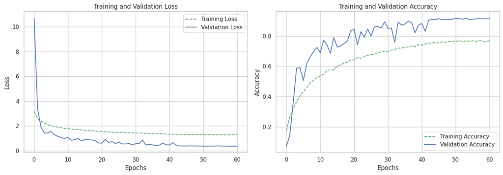

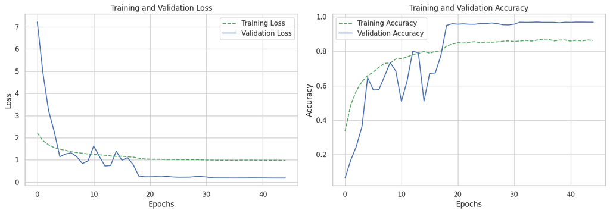

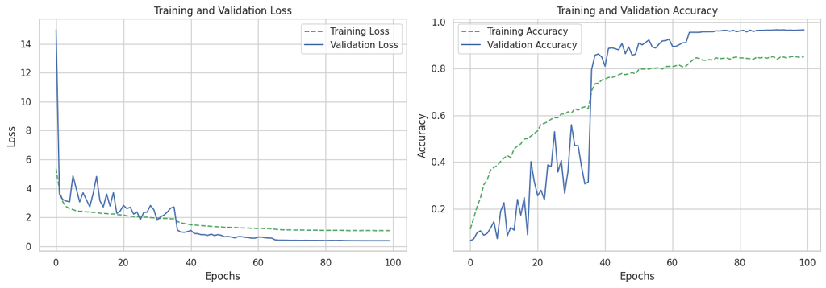

```python
for fig in figures_cutmix:
    fig()
```

#### Analysing of Results

```python
overall.iloc[-3:]
```

|  | Model Name | Epochs | Batch Size | Train Loss | Test Loss | Train Acc | Test Acc | Kappa | Comments |
| --- | --- | --- | --- | --- | --- | --- | --- | --- | --- |
| 6 | CNN cutmix | 61 | 128 | 1.301283 | 0.363114 | 0.761630 | 0.918667 | 0.918571 | NaN |
| 7 | CNN2 cutmix | 45 | 128 | 0.987957 | 0.187654 | 0.864754 | 0.970000 | 0.970000 | NaN |
| 8 | VGG_Baseline cutmix | 100 | 128 | 1.078563 | 0.375441 | 0.839721 | 0.965667 | 0.965357 | NaN |

### CutOut

- Cutout image augmentation is to randomly remove a square region of pixels in an input image during training

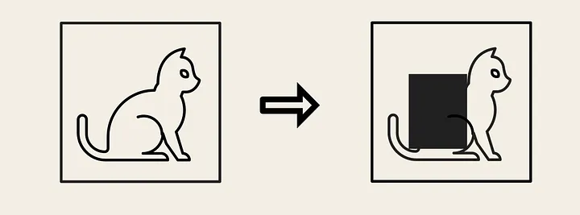

```python
def cutout(image, n_holes, length):
    height = tf.shape(image)[0]
    width = tf.shape(image)[1]

    mask = tf.ones((height, width), dtype=tf.float32)

    for _ in range(n_holes):
        y = tf.random.uniform([], 0, height, dtype=tf.int32)
        x = tf.random.uniform([], 0, width, dtype=tf.int32)

        y1 = tf.cast(tf.clip_by_value(y - length // 2, 0, height), tf.int32)
        y2 = tf.cast(tf.clip_by_value(y + length // 2, 0, height), tf.int32)
        x1 = tf.cast(tf.clip_by_value(x - length // 2, 0, width), tf.int32)
        x2 = tf.cast(tf.clip_by_value(x + length // 2, 0, width), tf.int32)

        # Creating a mask for the area to be cut out
        y_mask = (tf.range(height)[:, None] >= y1) & (tf.range(height)[:, None] < y2)
        x_mask = (tf.range(width)[None, :] >= x1) & (tf.range(width)[None, :] < x2)
        cutout_mask = y_mask & x_mask

        # Updating the mask
        mask = tf.where(cutout_mask, tf.zeros_like(mask), mask)

    mask = tf.expand_dims(mask, -1)  # Expanding to 3D to match image dimensions
    mask = tf.tile(mask, [1, 1, tf.shape(image)[-1]])  # Adjusting channels to match the image

    return image * mask
```

#### Set up the train and validation data

```python
train_ds_one = tf.data.Dataset.from_tensor_slices((X_train_small, y_train_small)).shuffle(2048).map(preprocess_data, num_parallel_calls=tf.data.AUTOTUNE)
train_ds_two = tf.data.Dataset.from_tensor_slices((X_train_small, y_train_small)).shuffle(2048).map(preprocess_data, num_parallel_calls=tf.data.AUTOTUNE)

val_ds_cutout = tf.data.Dataset.from_tensor_slices((X_val_small, y_val_small))
val_ds_cutout = val_ds_cutout.map(preprocess_data, num_parallel_calls=tf.data.AUTOTUNE)
val_ds_cutout = val_ds_cutout.map(lambda x, y: (cutout(x, n_holes=1, length=16), y), num_parallel_calls=tf.data.AUTOTUNE)
val_ds_cutout = val_ds_cutout.batch(128).prefetch(tf.data.AUTOTUNE)

train_ds_cutout = train_ds_one.map(lambda x, y: (cutout(x, n_holes=1, length=16), y), num_parallel_calls=tf.data.AUTOTUNE)
train_ds_cutout = train_ds_cutout.batch(128).prefetch(tf.data.AUTOTUNE)

image_batch, label_batch = next(iter(train_ds_cutout))
```

#### Visualisation of the augmented dataset

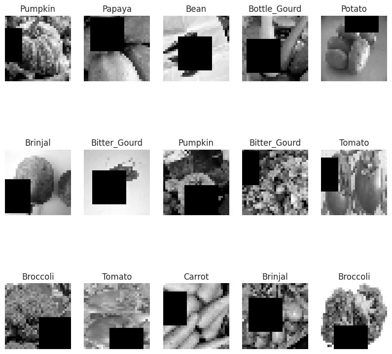

```python
plt.figure(figsize=(10, 10))
for i in range(15):
    ax = plt.subplot(3, 5, i + 1)
    plt.title(labels_dict[np.argmax(label_batch[i])])
    plt.imshow(tf.squeeze(image_batch[i]), cmap="gray")
    plt.axis("off")
plt.show()
```

#### Running the models

```python
models = models_array()
figures_cutout = []

for i in range(len(models)):
    print(f'Running {model_names[i]}')
    results, fig = evaluator.model_evaluate( train_ds_cutout, val_ds_cutout , models[i], base_hparams)
    results['Model Name'] = f'{model_names[i]} cutout'
    y_pred = models[i].predict(X_test_small)
    y_pred_classes = np.argmax(y_pred, axis=1)

    kappa = cohen_kappa_score(y_test_small, y_pred_classes)
    print("Cohen’s Kappa Score:", kappa)
    results['Kappa'] = kappa
    overall = pd.concat([overall, pd.DataFrame([results])], ignore_index=True)
    figures_cutout.append(fig)
```

```
Model: "sequential_16"
_________________________________________________________________
 Layer (type)                Output Shape              Param #
=================================================================
 conv2d_11 (Conv2D)          (None, 31, 31, 128)       1280

 batch_normalization_11 (Bat  (None, 31, 31, 128)      512
 chNormalization)

 re_lu_11 (ReLU)             (None, 31, 31, 128)       0

 conv2d_12 (Conv2D)          (None, 31, 31, 128)       147584

 batch_normalization_12 (Bat  (None, 31, 31, 128)      512
 chNormalization)

 re_lu_12 (ReLU)             (None, 31, 31, 128)       0

 conv2d_13 (Conv2D)          (None, 31, 31, 128)       147584

 batch_normalization_13 (Bat  (None, 31, 31, 128)      512
 chNormalization)

 re_lu_13 (ReLU)             (None, 31, 31, 128)       0

 conv2d_14 (Conv2D)          (None, 31, 31, 128)       147584

 batch_normalization_14 (Bat  (None, 31, 31, 128)      512
 chNormalization)

 re_lu_14 (ReLU)             (None, 31, 31, 128)       0

 conv2d_15 (Conv2D)          (None, 31, 31, 128)       147584

 batch_normalization_15 (Bat  (None, 31, 31, 128)      512
 chNormalization)

 re_lu_15 (ReLU)             (None, 31, 31, 128)       0

 global_average_pooling2d_1   (None, 128)              0
```

[output cut: 49 more lines]

```
 dropout_4 (Dropout)         (None, 128)               0

 dense_5 (Dense)             (None, 15)                1935

=================================================================
Total params: 3,357,199
Trainable params: 3,355,535
Non-trainable params: 1,664
_________________________________________________________________
Running CNN
Cohen’s Kappa Score: 0.9307142857142857
Running CNN2
Cohen’s Kappa Score: 0.9632142857142857
Running VGG_Baseline
Cohen’s Kappa Score: 0.9585714285714286
```